# Data Handling: Import, Cleaning and Visualisation

Lecture 3: Data Processing Basics

Lecturer

Dr. Aurélien Sallin

Published

August 2026

# Data Processing Basics

After lecture 3, we already have a much better understanding of what the `0`s and `1`s stand for, how they might enter the computer, where they might be stored on the computer, and where we might see the output of processing data on a computer.

## Components of a standard computing environment

Figure 1 illustrates the key components of a standard computing environment (PC, notebook, tablet, etc.) with which we can process data. A programming language (such as R) allows us to work with these hardware components (i.e., control them) in order to perform our tasks (e.g., cleaning/analyzing data).

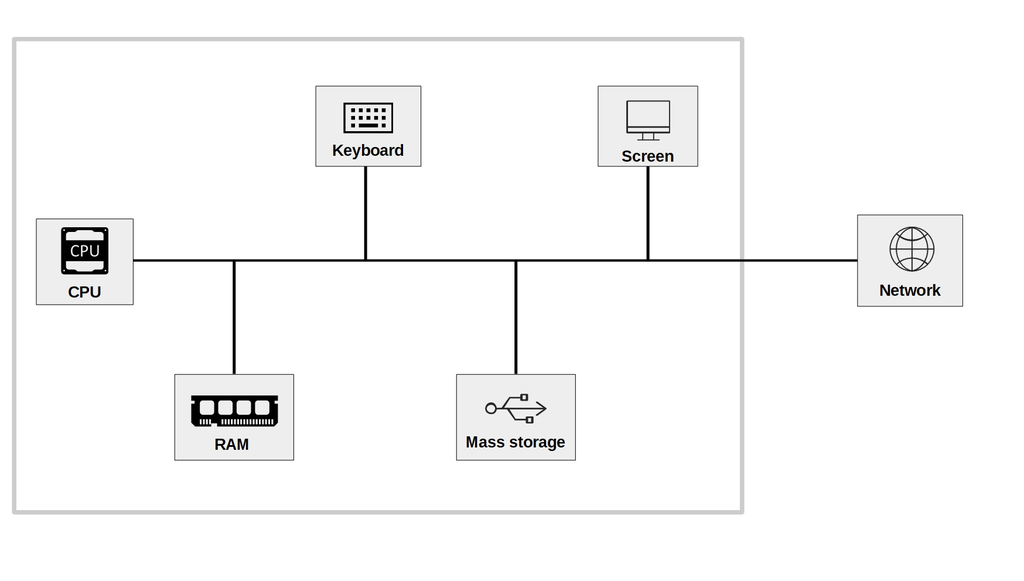

Figure 1: Basic components of a standard computing environment.

### Central Processing Unit

The component actually *processing* data is the Central Processing Unit (CPU). When using R to process data, R commands are translated into complex combinations of a small set of basic operations which the *CPU* then executes.

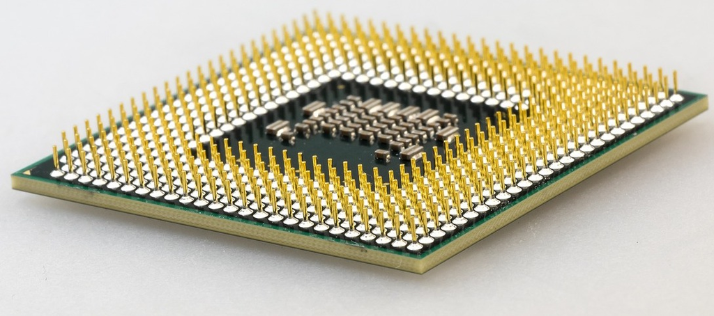

The CPU is the heart of the computer. It is the part of the machine that carries out the instructions of your program.

R runs on one CPU core by default, meaning that only one sequence of operations is executed at a time. Modern CPUs, however, have multiple cores, which allows several tasks to be processed in **parallel**. With the right R packages, such as `parallel`, `future`, or `data.table`, you can take advantage of multiple cores to speed up heavy computations like simulations, bootstrapping, or large data manipulations.

**Vectorized operations:** R is designed to work efficiently with vectors, that is, with many values at once. Instead of processing one number after another, R can often apply the same operation to an entire vector in a single step (SIMD: Single Instruction, Multiple Data). This allows the CPU to work more efficiently and is one reason why vectorized R code is usually much faster than using explicit loops.

```r
# Vectorized operation:
scores <- c(72, 85, 90, 68, 77)
scores + 5

# Non-vectorized (through loops)
new_scores <- numeric(length(scores))

for (i in 1:length(scores)) {
  new_scores[i] <- scores[i] + 5
}

new_scores

# In vectorized operations, R tells the CPU to apply the same instruction to many
# values at once, instead of handling them one by one.
```

```
[1] 77 90 95 73 82
[1] 77 90 95 73 82
```

**The speed of a CPU** is often described by its clock speed, measured in gigahertz (GHz). A CPU running at 3 GHz can perform roughly three billion basic steps per second. This is important because many R operations use only one core, so the speed of a single core often matters more than the total number of cores.

**Memory hierarchy:** the CPU works fastest when the data it needs is close to it. For this reason, computers use different types of memory with different speeds and sizes. Very small but extremely fast memory is located directly inside the CPU. Slightly larger but still fast memory (called cache) sits just outside it. Below that is RAM, which can store much more data but is slower to access. At the bottom are storage devices such as SSDs or hard drives, which are much larger but far slower than RAM.

**Example:** when you open a dataset in R, it is first read from the hard drive or SSD into RAM. When you run a function, the CPU temporarily copies small parts of the data from RAM into its fast internal memory to perform the calculations. If a dataset is too large to fit into RAM, R will become very slow or stop with an “out of memory” error.

### Mass storage: hard drive

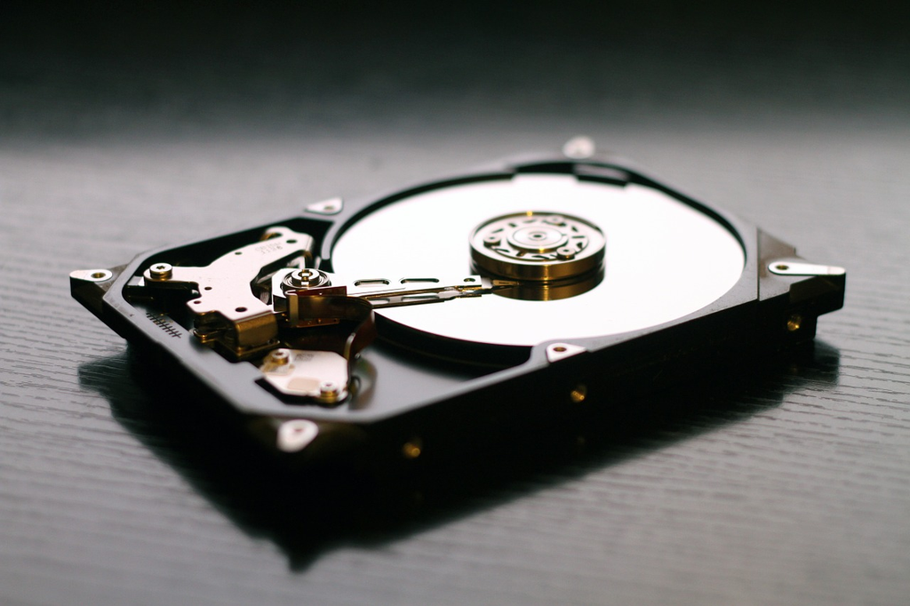

This is where the data (and operating system, software, etc.) is stored in the long run. When you boot your computer, the core programs needed to run the computer are loaded from the hard drive into RAM. When you *import* a dataset into R/RStudio, the data is read from a (text-)file stored on the hard drive into RAM.

Simple example of difference between RAM and hard drive: When you open a new R-Script (or Word-file, etc.), type something in it, this means you write something to an object located somewhere in RAM. If you close the application without saving the file, it will be lost. Once you “save” the script/document, it will be written to the hard drive.

**Units of information/data storage:** the question of how to store digital data on computers also raises the question of storage capacity. The smallest unit of information in computing (stored as a `0` or a `1`) is a *bit* (from *bi*nary dig*it*; abbrev. ‘b’). A *byte* is 8 bits (1 byte = 8 bits; abbrev. ‘B’). For example: to store the decimal number `139`, which corresponds to the binary number `10001011`, we require a capacity of 8 bits or one *byte*.

Historically, one byte encoded a single character of text (ASCII). 4 bytes (32 bits) are called a *word*.

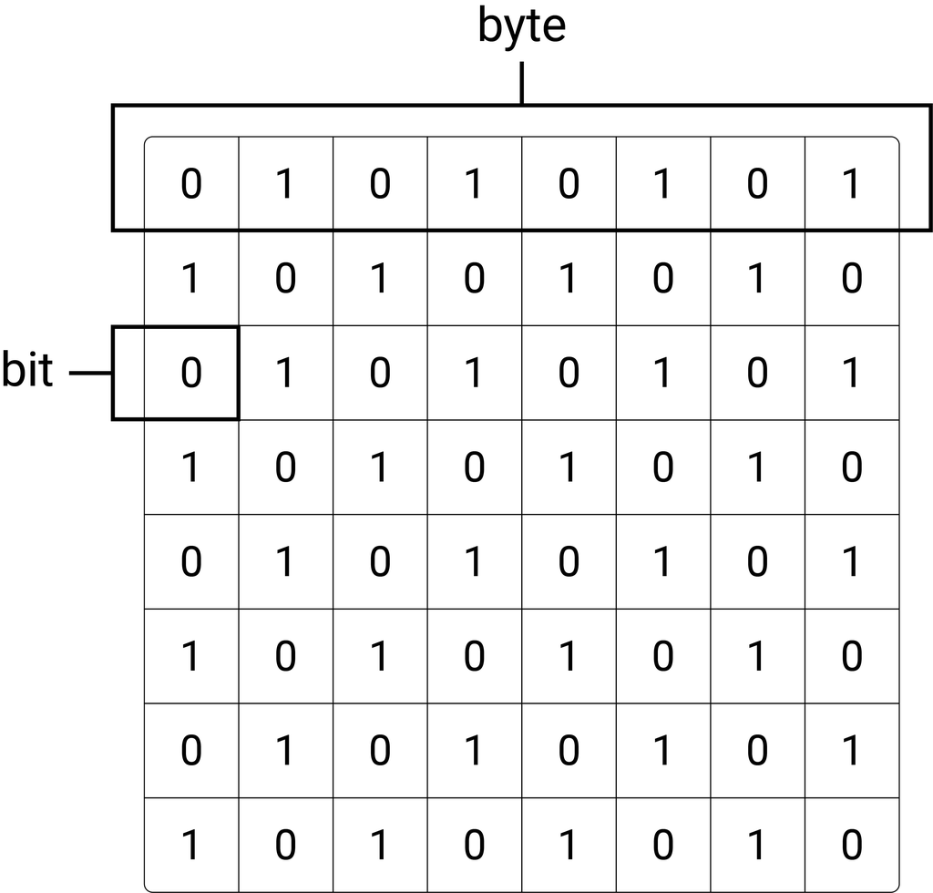

Bigger units for storage capacity usually build on bytes:

- 1 kilobyte (KB) = $1000^{1}$ bytes $\approx 2^{10}$ bytes
- 1 megabyte (MB) = $1000^{2}$ bytes $\approx 2^{20}$ bytes
- 1 gigabyte (GB) = $1000^{3}$ bytes $\approx 2^{30}$ bytes
- 1 terabyte (TB) = $1000^{4}$ bytes $\approx 2^{40}$ bytes
- 1 petabyte (PB) = $1000^{5}$ bytes $\approx 2^{50}$ bytes
- 1 exabyte (EB) = $1000^{6}$ bytes $\approx 2^{60}$ bytes
- 1 zettabyte (ZB) = $1000^{7}$ bytes $\approx 2^{70}$ bytes

1 ZB = 1000000000000000000000 bytes = 1 billion terabytes = 1 trillion gigabytes.

You might wonder why we are using an approximation here. The concepts of kilobytes, megabytes, gigabytes, …, are related to the concepts of kibibytes, mebibytes, gibibytes, … (based on powers of 2 instead of powers of 10).

- 1 kibibyte (KiB) = $2^{10}$ = 1’024 bytes
- 1 mebibyte (MiB) = $2^{20}$ = 1’048’576 bytes
- 1 gibibyte (GiB) = $2^{30}$ = 1’073’741’824 bytes

In practice, the two concepts are often used interchangeably in informal language, but they are distinct standards. The confusion between the two concepts is a common source of misunderstanding. For example, a computer described to have 512-megabyte of RAM has 512 MiB, which is $512 * 2^{20}$ bytes, and not $512 * 10^6$ bytes of RAM. For more information, see the [Wikipedia page on Binary Prefixes](https://en.wikipedia.org/wiki/Binary_prefix).

### Random Access Memory

To work with data (e.g., in R), it first must be loaded into the *memory* of our computer. More specifically, into the Random Access Memory (*RAM*). Typically, data is only loaded in the RAM as long as we work with it.

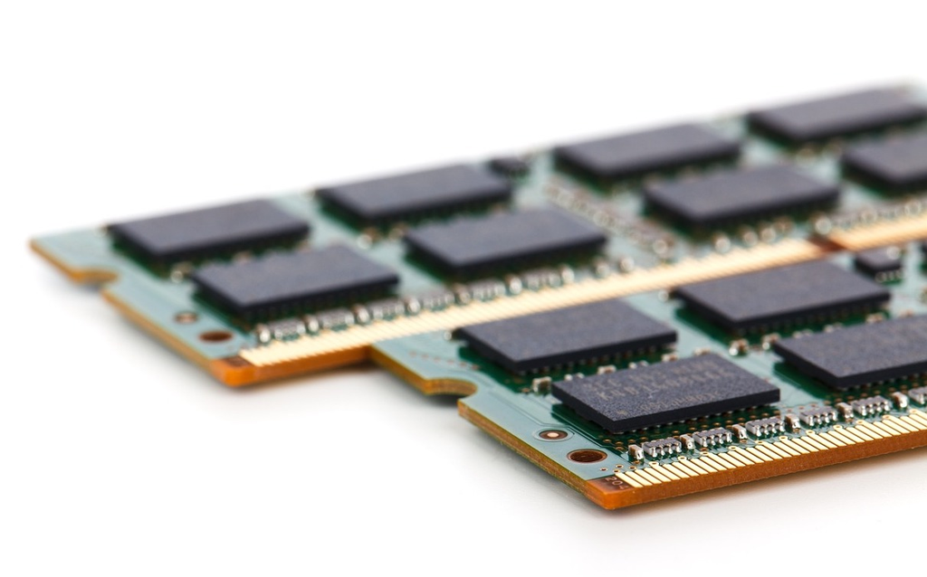

RAM holds all objects that are currently in use, such as datasets, variables, and environments. It provides the data that the CPU is working on at any given moment. RAM is filled when you start your computer and is cleared when you shut it down.

Most standard data analysis techniques assume that the entire dataset, and often additional intermediate results, fit into RAM. When working with very large datasets, this can become a limitation.

**Example of RAM limitation:** To illustrate the importance of RAM, consider the following example: in `R`, we try to create a matrix with $10^5 \times 10^5$ elements:

```r
# This will almost certainly fail on a typical laptop
large_matrix <- matrix(1, nrow=1e5, ncol=1e5)
```

```
Error: cannot allocate vector of size 74.5 Gb
```

💣💥💣💥💣💥 Assuming each number is stored using 8 bytes, this matrix would require $8\times10^{10}$ bytes of RAM. This is 80 gigabytes (GB). Most computers today have between 8 and 64 gigabytes (GB) of RAM.

### Network: Internet, cloud, etc.

[figure not shown]

With today’s abundance of digital data on all kinds of economic activities, many economic research projects rely on either gathering the raw data from web sources and/or on storing the data for analytics purposes on a database or simple storage service in the web/in the cloud. In practice, datasets for analytics purposes are thus often transferred between a web source and the local hard drive, or directly read from a web source into RAM.

## Putting the pieces together…

Recall the initial example (survey) of this course.

1. Access a website (over the Internet), use keyboard to enter data into a website (a Google sheet in that case). That is, data is typed into RAM and then transferred over a network connection to a web server, and stored on its hard drive.
2. An R program accesses the data of the Google sheet (again over the Internet), downloads the data, and loads it into RAM.
3. Data processing: an R program is run through the CPU to produce output (in the form of statistics/plots), the output is shown on screen.